# Создание модели предсказания уровеня удовлетворённости сотрудника

### Корреляционный анализ

```python
def phik_matrix(df, list_of_interval_cols):
    plt.figure(figsize=(15, 6))
    phik_matrix = df.phik_matrix(interval_cols=list_of_interval_cols)
    masking = np.triu(np.ones_like(phik_matrix, dtype=bool), k=1)
    sns.heatmap(data=phik_matrix, mask=masking, annot=True, cmap='coolwarm', fmt='.2f');
```

Рассчитаем значения корреляции хи-квадрат между признаками:

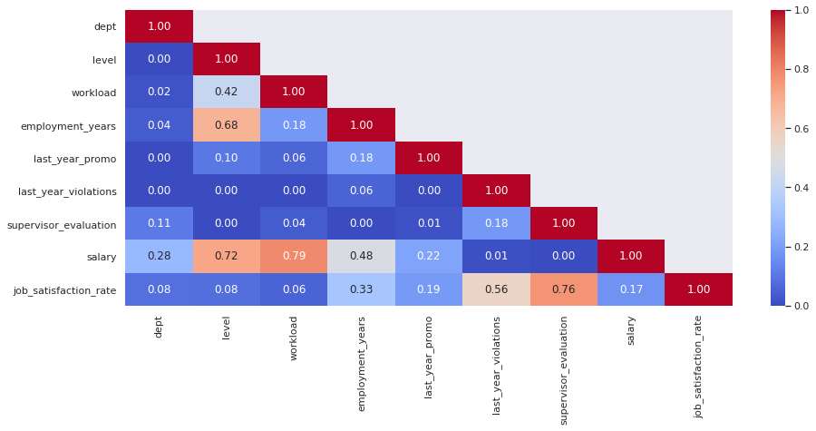

```python
phik_matrix(df_train, list_of_interval_cols=['salary', 'job_satisfaction_rate'])
```

Так как все значения хи-квадрат менее 0,9, следовательно, мультиколлинеарности между признаками в датасете *df_train* не обнаружено.

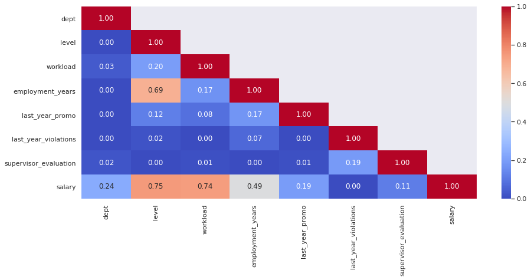

```python
phik_matrix(df_test_features, list_of_interval_cols=['salary'])
```

Аналогично для датасета *df_test_features*, мультиколлинераности между признаками не обнаружено.

### Подготовка данных

Проверим данные на наличие строк-дубликатов.

```python
df_train.duplicated().sum()
```

```
245
```

Удалим все дубликаты, а также объединим *df_test_features* и *df_test_target* в один датасет *df_test*.

```python
df_train.drop_duplicates(inplace=True)
```

```python
df_test = df_test_features.join(df_test_target)
df_test.head()
```

| id | dept | level | workload | employment_years | last_year_promo | last_year_violations | supervisor_evaluation | salary | job_satisfaction_rate |
| --- | --- | --- | --- | --- | --- | --- | --- | --- | --- |
| 485046 | marketing | junior | medium | 2 | no | no | 5 | 28800 | 0.79 |
| 686555 | hr | junior | medium | 1 | no | no | 4 | 30000 | 0.72 |
| 467458 | sales | middle | low | 5 | no | no | 4 | 19200 | 0.64 |
| 418655 | sales | middle | low | 6 | no | no | 4 | 19200 | 0.60 |
| 789145 | hr | middle | medium | 5 | no | no | 5 | 40800 | 0.75 |

```python
X_train = df_train.drop('job_satisfaction_rate', axis=1)
y_train = df_train['job_satisfaction_rate']

X_test = df_test.drop('job_satisfaction_rate', axis=1)
y_test = df_test['job_satisfaction_rate']
```

```python
ohe_columns = ['dept',
              'last_year_promo',
              'last_year_violations']

ord_columns = ['supervisor_evaluation',
              'workload',
              'level']

num_columns = ['employment_years',
              'salary']
```

```python
def replace_space_with_nan(X):
    return X.replace(' ', np.NaN)
```

```python
# replace_space_with_nan + SimpleImputer + OHE
ohe_pipe = Pipeline(
    [('replace_spaces', FunctionTransformer(replace_space_with_nan, feature_names_out='one-to-one')),
     ('simpleImputer_ohe', SimpleImputer(missing_values=np.nan, strategy='most_frequent')),
     ('ohe', OneHotEncoder(drop='first', handle_unknown='ignore', sparse=False))
    ]
)
# SimpleImputer + OE
ord_pipe = Pipeline(
    [('simpleImputer_before_ord', SimpleImputer(missing_values=np.nan, strategy='most_frequent')),
     ('ord',  OrdinalEncoder(categories=[
                    [1, 2, 3, 4, 5],
                    ['low', 'medium', 'high'],
                    ['junior', 'middle', 'sinior']],
                handle_unknown='use_encoded_value', unknown_value=np.nan)),
     ('simpleImputer_after_ord', SimpleImputer(missing_values=np.nan, strategy='most_frequent'))
    ]
)
```

```python
data_preprocessor = ColumnTransformer(
    [('ohe', ohe_pipe, ohe_columns),
     ('ord', ord_pipe, ord_columns),
     ('num', MinMaxScaler(), num_columns),
    ],
    remainder='passthrough'
)
```

```python
pipe_final = Pipeline([
    ('preprocessor', data_preprocessor),
    ('models', DecisionTreeRegressor(random_state=RANDOM_STATE))
])
```

### Обучение моделей

```python
param_grid = [

    # словарь для модели LinearRegression()
    {
        'models': [LinearRegression()],
        'preprocessor__num': [StandardScaler(), MinMaxScaler(), 'passthrough']
    },

    # словарь для модели DecisionTreeRegressor()
    {
        'models': [DecisionTreeRegressor(random_state=RANDOM_STATE)],
        'models__max_depth': range(10, 20),
        'models__max_features': range(2, 12),
        'preprocessor__num': [StandardScaler(), MinMaxScaler(), 'passthrough']
    },

    # словарь для модели KNeighborsRegressor()
    {
        'models': [KNeighborsRegressor()],
        'models__n_neighbors': range(2, 6),
        'preprocessor__num': [StandardScaler(), MinMaxScaler(), 'passthrough']
    }
]
```

Создадим функцию симметричного среднего абсолютного процентного отклонения для оценки качества нашей модели.

```python
def smape(y_true, y_pred):
    assert len(y_true) == len(y_pred), 'the length of the arrays does not match'
    return 100 / len(y_true) * np.sum(2 * np.abs(y_true - y_pred) / (np.abs(y_true) + np.abs(y_pred)))
```

```python
smape_scorer = make_scorer(smape, greater_is_better=False)
```

```python
gs = GridSearchCV(
    pipe_final,
    param_grid,
    cv=5,
    scoring=smape_scorer,
    n_jobs=-1
)
gs.fit(X_train, y_train)
```

```
GridSearchCV(cv=5,
             estimator=Pipeline(steps=[('preprocessor',
                                        ColumnTransformer(remainder='passthrough',
                                                          transformers=[('ohe',
                                                                         Pipeline(steps=[('replace_spaces',
                                                                                          FunctionTransformer(feature_names_out='one-to-one',
                                                                                                              func=<function replace_space_with_nan at 0x7f23cf677700>)),
                                                                                         ('simpleImputer_ohe',
                                                                                          SimpleImputer(strategy='most_frequent')),
                                                                                         ('ohe',
                                                                                          OneHotEncoder(dro...
                                                           max_features=11,
                                                           random_state=42)],
                          'models__max_depth': range(10, 20),
                          'models__max_features': range(2, 12),
                          'preprocessor__num': [StandardScaler(),
                                                MinMaxScaler(),
                                                'passthrough']},
                         {'models': [KNeighborsRegressor()],
                          'models__n_neighbors': range(2, 6),
                          'preprocessor__num': [StandardScaler(),
                                                MinMaxScaler(),
                                                'passthrough']}],
             scoring=make_scorer(smape, greater_is_better=False))
```

```python
print('Лучшая модель и её параметры:\n\n', gs.best_estimator_)
print ('Метрика лучшей модели SMAPE при кросс-валидации:', round(-gs.best_score_, 3))
```

```
Лучшая модель и её параметры:

 Pipeline(steps=[('preprocessor',
                 ColumnTransformer(remainder='passthrough',
                                   transformers=[('ohe',
                                                  Pipeline(steps=[('replace_spaces',
                                                                   FunctionTransformer(feature_names_out='one-to-one',
                                                                                       func=<function replace_space_with_nan at 0x7f23cf677700>)),
                                                                  ('simpleImputer_ohe',
                                                                   SimpleImputer(strategy='most_frequent')),
                                                                  ('ohe',
                                                                   OneHotEncoder(drop='first',
                                                                                 handle_unknown='ig...
                                                                                               'medium',
                                                                                               'high'],
                                                                                              ['junior',
                                                                                               'middle',
                                                                                               'sinior']],
                                                                                  handle_unknown='use_encoded_value',
                                                                                  unknown_value=nan)),
                                                                  ('simpleImputer_after_ord',
                                                                   SimpleImputer(strategy='most_frequent'))]),
                                                  ['supervisor_evaluation',
                                                   'workload', 'level']),
                                                 ('num', MinMaxScaler(),
                                                  ['employment_years',
                                                   'salary'])])),
                ('models',
                 DecisionTreeRegressor(max_depth=14, max_features=11,
                                       random_state=42))])
Метрика лучшей модели SMAPE при кросс-валидации: 15.916
```

```python
y_pred = gs.predict(X_test)
y_true = y_test
print('Метрика лучшей модели SMAPE на тестовой выборке:', round(smape(y_true, y_pred), 3))
```

```
Метрика лучшей модели SMAPE на тестовой выборке: 14.59
```

**Вывод:** В ходе моделирования была найдена и обучена модель для определения удовлетворенности сотрудника работой. Лучшие результаты показала модель дерева решений **DecisionTreeRegressor(max_depth=14, max_features=11, random_state=42)**. Её показатели метрики SMAPE для тренировочной выборки - 15.916, для тестовой выборки - 14.59. Модель преодолела порог в 15 на тестовой выборке, поэтому можно утверждать, что модель успешно обучилась.